# TCR beta chain diversity in tumor-infiltrating lymphocytes

# Preparation steps

#### Package loading

```r
suppressMessages({
  library(data.table)
  library(pheatmap)
  library(stringdist)
  library(igraph)
  library(circlize)
  library(tidyverse)
  library(ggthemes)
  options(stringsAsFactors = F)
  library(rdi)
  library(corrplot)
  library(vegan)
})
```

#### Data loading

###### Results from IgBlast analysis

```r
igblast_files <- list.files('igblast/', full.names = T)
igblast_results <- igblast_files %>%
  lapply(read.delim)
```

###### Sample information

```r
meta <- read.csv('meta/GSE126278_meta.csv')
```

###### Attribute sample names to respective tables based on metadata information

```r
(names(igblast_results) <- sub('igblast/', '', igblast_files) %>%
  substr(1, 10) %>%
  {meta$Sample[match(meta$Run, .)]})
```

```
[1] "GSM3595657" "GSM3595658" "GSM3595659" "GSM3595660" "GSM3595661" "GSM3595662"
```

# Introduction

## Data source

https://www.ncbi.nlm.nih.gov/geo/query/acc.cgi?acc=GSM3595657

Data was downloaded from SRA using sratoolkit in split files corresponding to paired-end sequencing 2x300

## Supplied information

### Treatment protocol

C57BL/6 mice were inoculated subcutaneously with tumor cells (MO4; an ovalbumin (OVA)-expressing B16F10 melanoma cell line of C57BL/6 origin) into the right and left hindlimb simultaneously (1 × 10^5) on day 0. On day 5, when tumors were palpable, mice were treated peritumorally with IFN-α-iPSC-pMCs (1 × 10^6) into the right hindlimb on days 5, 6, 7, 12, and 13. Total RNA from tumor tissue was extracted on day 14.

### Extraction protocol

Total RNA was extracted with the RNeasy Mini Kit Plus (Qiagen, Valencia, CA, USA). Total RNA was converted to complementary DNA (cDNA) with Superscript III reverse transcriptase (Invitrogen, Carlsbad, California, USA). Then, double strand (ds)-cDNA was synthesized and an adaptor was ligated to the 5′ end of the ds-cDNA and cut with SphI restriction enzyme. For TCRβ, PCR was performed with a P20EA adaptor primer and a TCRβ-chain constant region-specific primer (mCB1). The second PCR was performed with mCB2 and P20EA primers using the same PCR conditions. After Tag PCR amplification, index (barcode) sequences were added by amplification with a Nextera XT Index Kit v2 setA (Illumina, San Diego, California, USA). Sequence was done with the Illumina MiSeq paired-end platform (2×300 base pairs (bp)).

## Data Processing

Corresponding paired end reads with at least 20 nucleotides of overlap were merged using the pandaseq tool. Low quality sequences were filtered out and quality statistics of resulting reads obtained using the fastx toolkit. Quality filtering was performed after read merging to avoid discarding low quality sequences that could be rescued by overlap with their mate. The remaining sequences were queried against the IMGT database of TRB genes using igblast.

# Data preprocessing

## Data exploration and QC

```r
igblast_results[[1]][1:5, ]
```

|  | sequence_id | sequence | locus | stop_codon | vj_in_frame | productive | rev_comp | v_call | d_call | j_call | sequence_alignment | germline_alignment | sequence_alignment_aa | germline_alignment_aa | v_alignment_start | v_alignment_end | d_alignment_start | d_alignment_end | j_alignment_start | j_alignment_end | v_sequence_alignment | v_sequence_alignment_aa | v_germline_alignment | v_germline_alignment_aa | d_sequence_alignment | d_sequence_alignment_aa | d_germline_alignment | d_germline_alignment_aa | j_sequence_alignment | … |
| --- | --- | --- | --- | --- | --- | --- | --- | --- | --- | --- | --- | --- | --- | --- | --- | --- | --- | --- | --- | --- | --- | --- | --- | --- | --- | --- | --- | --- | --- | --- |
| 1 | SRR8550225:::44:0:0:0:;0.891135 | CTAATACGACTCCGAATTCCCACGCATCCTGAGAAGAAGCATGTCCAACACTGTCCTCGC…… | TRB | FALSE | TRUE | TRUE | TRUE | TRBV12-1*01 |  | TRBJ2-3*01 | GATTCTGGGGTTGTCCAGTCTCCAAGACACATAATCAAAGAAAAGGGAGGAAGGGCCGTT…… | GATTCTGGGGTTGTCCAGTCTCCAAGACACATAATCAAAGAAAAGGGAGGAAGGTCCGTT…… | DSGVVQSPRHIIKEKGGRAVLTCIPIPGHSNVVWYQQTLGKELKFLIQHYEKVERDKGFLPSRFSVQQFDDYHSEMNMRALELEDSAMYFCASSPNSAETLYFGSGTRLTVL | DSGVVQSPRHIIKEKGGRSVLTCIPISGHSNVVWYQQTLGKELKFLIQHYEKVERDKGFLPSRFSVQQFDDYHSEMNMSALELEDSAMYFCASSXXSAETLYFGSGTRLTVL | 1 | 281 | NA | NA | 289 | 337 | GATTCTGGGGTTGTCCAGTCTCCAAGACACATAATCAAAGAAAAGGGAGGAAGGGCCGTT…… | DSGVVQSPRHIIKEKGGRAVLTCIPIPGHSNVVWYQQTLGKELKFLIQHYEKVERDKGFLPSRFSVQQFDDYHSEMNMRALELEDSAMYFCASS | GATTCTGGGGTTGTCCAGTCTCCAAGACACATAATCAAAGAAAAGGGAGGAAGGTCCGTT…… | DSGVVQSPRHIIKEKGGRSVLTCIPISGHSNVVWYQQTLGKELKFLIQHYEKVERDKGFLPSRFSVQQFDDYHSEMNMSALELEDSAMYFCASS |  |  |  |  | AGTGCAGAAACGCTGTATTTTGGCTCAGGAACCAGACTGACTGTTCTCG | … |
| 2 | SRR8550225:::52:0:0:0:;0.809257 | CTAATACGACTCCGAATTCCCCCCGCCTGGAACACCACCCTGCTATCTTGGGTTGCTCTC…… | TRB | FALSE | TRUE | TRUE | TRUE | TRBV13-2*01 | TRBD2*01 | TRBJ2-7*01 | GAGGCTGCAGTCACCCAAAGCCCAAGAAACAAGGTGGCAGTAACAGGAGGAAAGGTGACA…… | GAGGCTGCAGTCACCCAAAGCCCAAGAAACAAGGTGGCAGTAACAGGAGGAAAGGTGACA…… | EAAVTQSPRNKVAVTGGKVTLSCNQTNNHNNMYWYRQDTGHGLRLIHYSYGAGSTEKGDIPDGYKASRPSQENFSLILELATPSQTSVYFCASGDAGVYEQYFGPGTRLTVL | EAAVTQSPRNKVAVTGGKVTLSCNQTNNHNNMYWYRQDTGHGLRLIHYSYGAGSTEKGDIPDGYKASRPSQENFSLILELATPSQTSVYFCASGDAGXYEQYFGPGTRLTVL | 1 | 286 | 287 | 292 | 294 | 337 | GAGGCTGCAGTCACCCAAAGCCCAAGAAACAAGGTGGCAGTAACAGGAGGAAAGGTGACA…… | EAAVTQSPRNKVAVTGGKVTLSCNQTNNHNNMYWYRQDTGHGLRLIHYSYGAGSTEKGDIPDGYKASRPSQENFSLILELATPSQTSVYFCASGD | GAGGCTGCAGTCACCCAAAGCCCAAGAAACAAGGTGGCAGTAACAGGAGGAAAGGTGACA…… | EAAVTQSPRNKVAVTGGKVTLSCNQTNNHNNMYWYRQDTGHGLRLIHYSYGAGSTEKGDIPDGYKASRPSQENFSLILELATPSQTSVYFCASGD | CTGGGG | G | CTGGGG | G | CTATGAACAGTACTTCGGTCCCGGCACCAGGCTCACGGTTTTAG | … |
| 3 | SRR8550225:::34:0:0:0:;0.752452 | CTAATACGACTCCGAATTCCCGTCTAACACTGCCTTCCCTGACCTCGCCTGGAACACCAC…… | TRB | FALSE | TRUE | TRUE | TRUE | TRBV13-2*01 | TRBD1*01 | TRBJ2-4*01 | GAGGCTGCAGTCACCCAAAGCCCAAGAAACAAGGTGGCAGTAACAGGAGGAAAGTTTACA…… | GAGGCTGCAGTCACCCAAAGCCCAAGAAACAAGGTGGCAGTAACAGGAGGAAAGGTGACA…… | EAAVTQSPRNKVAVTGGKFTFCCNQSNNHNNVYWYRQDTGHGLRLIHYSYGAGSTEKGDIPDGYKASRPSQENFSLILELANPSQTSVYFCASGDATGNQNTLYFGAGTRLSVL | EAAVTQSPRNKVAVTGGKVTLSCNQTNNHNNMYWYRQDTGHGLRLIHYSYGAGSTEKGDIPDGYKASRPSQENFSLILELATPSQTSVYFCASGDXTGXQNTLYFGAGTRLSVL | 1 | 286 | 289 | 294 | 297 | 343 | GAGGCTGCAGTCACCCAAAGCCCAAGAAACAAGGTGGCAGTAACAGGAGGAAAGTTTACA…… | EAAVTQSPRNKVAVTGGKFTFCCNQSNNHNNVYWYRQDTGHGLRLIHYSYGAGSTEKGDIPDGYKASRPSQENFSLILELANPSQTSVYFCASGD | GAGGCTGCAGTCACCCAAAGCCCAAGAAACAAGGTGGCAGTAACAGGAGGAAAGGTGACA…… | EAAVTQSPRNKVAVTGGKVTLSCNQTNNHNNMYWYRQDTGHGLRLIHYSYGAGSTEKGDIPDGYKASRPSQENFSLILELATPSQTSVYFCASGD | ACAGGG | TG | ACAGGG | TG | TCAAAACACCTTGTACTTTGGTGCGGGCACCCGACTATCGGTGCTAG | … |
| 4 | SRR8550225:::62:0:0:0:;0.884914 | CTAATACGACTCCGAATTCCCTGCCCCACAGAGATAGAGAGAACCTGAGGTCTCAGAGAT…… | TRB | FALSE | TRUE | TRUE | TRUE | TRBV1*01 | TRBD1*01 | TRBJ2-3*01 | GTGACTTTGCTGGAGCAAAACCCAAGGTGGCGTCTGGTACCACGTGGTCAAGCTGTGAAC…… | GTGACTTTGCTGGAGCAAAACCCAAGGTGGCGTCTGGTACCACGTGGTCAAGCTGTGAAC…… | VTLLEQNPRWRLVPRGQAVNLRCILKNSQYPWMSWYQQDLQKQLQWLFTLRSPGDKEVKSLPGADYLATRVTDTELRLQVANMSQGRTLYCTCRPGRGAETLYFGSGTRLTVF | VTLLEQNPRWRLVPRGQAVNLRCILKNSQYPWMSWYQQDLQKQLQWLFTLRSPGDKEVKSLPGADYLATRVTDTELRLQVANMSQGRTLYCTCXXGXXAETLYFGSGTRLTVL | 1 | 281 | 285 | 289 | 293 | 340 | GTGACTTTGCTGGAGCAAAACCCAAGGTGGCGTCTGGTACCACGTGGTCAAGCTGTGAAC…… | VTLLEQNPRWRLVPRGQAVNLRCILKNSQYPWMSWYQQDLQKQLQWLFTLRSPGDKEVKSLPGADYLATRVTDTELRLQVANMSQGRTLYCTC | GTGACTTTGCTGGAGCAAAACCCAAGGTGGCGTCTGGTACCACGTGGTCAAGCTGTGAAC…… | VTLLEQNPRWRLVPRGQAVNLRCILKNSQYPWMSWYQQDLQKQLQWLFTLRSPGDKEVKSLPGADYLATRVTDTELRLQVANMSQGRTLYCTC | GGGAC | G | GGGAC | G | GTGCAGAAACGCTGTATTTTGGCTCAGGAACCAGACTGACTGTTTTCG | … |
| 5 | SRR8550225:::81:0:0:0:;0.810574 | GTTGGGTGGAGTCACATTTCTCAGATCCTCTGATGTTCCACATTCACTCCTACACTGAGA…… | TRA | TRUE | NA | FALSE | FALSE | TRBV13-2*05 |  |  | CCCGACCCCCATTGTGCAAGGTGGTGGTAA | CCCAAAGCCCAAGAAGCAAGGTGGCAGTAA | PDPHCARWW* | PKAQEARWQ* | 1 | 30 | NA | NA | NA | NA | CCCGACCCCCATTGTGCAAGGTGGTGGTAA | PDPHCARWW* | CCCAAAGCCCAAGAAGCAAGGTGGCAGTAA | PKAQEARWQ* |  |  |  |  |  | … |

```r
colnames(igblast_results[[1]])
```

```
 [1] "sequence_id"             "sequence"                "locus"                   "stop_codon"
 [5] "vj_in_frame"             "productive"              "rev_comp"                "v_call"
 [9] "d_call"                  "j_call"                  "sequence_alignment"      "germline_alignment"
[13] "sequence_alignment_aa"   "germline_alignment_aa"   "v_alignment_start"       "v_alignment_end"
[17] "d_alignment_start"       "d_alignment_end"         "j_alignment_start"       "j_alignment_end"
[21] "v_sequence_alignment"    "v_sequence_alignment_aa" "v_germline_alignment"    "v_germline_alignment_aa"
[25] "d_sequence_alignment"    "d_sequence_alignment_aa" "d_germline_alignment"    "d_germline_alignment_aa"
[29] "j_sequence_alignment"    "j_sequence_alignment_aa" "j_germline_alignment"    "j_germline_alignment_aa"
[33] "fwr1"                    "fwr1_aa"                 "cdr1"                    "cdr1_aa"
[37] "fwr2"                    "fwr2_aa"                 "cdr2"                    "cdr2_aa"
[41] "fwr3"                    "fwr3_aa"                 "fwr4"                    "fwr4_aa"
[45] "cdr3"                    "cdr3_aa"                 "junction"                "junction_length"
[49] "junction_aa"             "junction_aa_length"      "v_score"                 "d_score"
[53] "j_score"                 "v_cigar"                 "d_cigar"                 "j_cigar"
[57] "v_support"               "d_support"               "j_support"               "v_identity"
[61] "d_identity"              "j_identity"              "v_sequence_start"        "v_sequence_end"
[65] "v_germline_start"        "v_germline_end"          "d_sequence_start"        "d_sequence_end"
[69] "d_germline_start"        "d_germline_end"          "j_sequence_start"        "j_sequence_end"
[73] "j_germline_start"        "j_germline_end"          "fwr1_start"              "fwr1_end"
[77] "cdr1_start"              "cdr1_end"                "fwr2_start"              "fwr2_end"
[81] "cdr2_start"              "cdr2_end"                "fwr3_start"              "fwr3_end"
[85] "fwr4_start"              "fwr4_end"                "cdr3_start"              "cdr3_end"
[89] "np1"                     "np1_length"              "np2"                     "np2_length"
```

Despite using only TRB sequences for reference database, the locus call can sometimes refer to a different chain. This is probably due to extra meta-data utilized by igblast outside of the database itself. To generate preliminary statistics, we are going to look at proportions of sequences mapped to the correct locus, and productivity status. We will also look at the proportion of productive chains when the TRB locus is called correctly as opposed to when a different locus is called.

### Proportion of correctly called loci in all samples

#### Plot

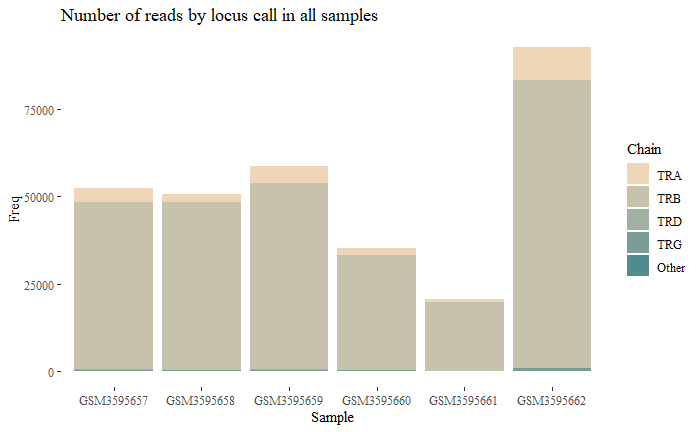

```r
# Count occurences of locus calls in all tables and add a column for sample ID
lapply(seq_along(igblast_results), function(i) {
  table(igblast_results[[i]]$locus) %>%
  as.data.frame() %>% data.frame(Sample = names(igblast_results)[i])
}) %>%
# Generate a unique table and clean up the Var1 column (change name, change empty string to 'Other', relevel)
  bind_rows() %>%
  {
    colnames(.)[1] <- 'Chain'
    .[, 'Chain'] <- as.character(.[, 'Chain'])
    .$Chain[.$Chain == ''] <- 'Other'
    .$Chain <- factor(.$Chain, levels=c('TRA', 'TRB', 'TRD', 'TRG', 'Other'))
    .
  } %>%
# Plot
  ggplot(aes(x=Sample, y=Freq, fill=Chain)) +
  geom_bar(stat='identity', position='stack') +
  theme_tufte() +
  scale_fill_manual(values=colorRampPalette(c('bisque2', 'darkslategray4'))(5)) +
  ggtitle('Number of reads by locus call in all samples')
```

#### Table

```r
# Count occurences of locus calls in all tables and clean up
lapply(seq_along(igblast_results), function(i) {
  table(igblast_results[[i]]$locus) %>%
  as.data.frame() %>% {
    colnames(.) <- c('Chain', names(igblast_results)[i])
    .$Chain <- as.character(.$Chain)
    .$Chain[.$Chain == ''] <- 'Other'
    .
  }
# Merge all data tables
}) %>%
  {
    Reduce(function(...) merge(..., by='Chain'), .)
    } %>%
# Transform to percentage
  {
    .[2:7] <- sapply(.[2:7], function(x) round(100*x/sum(x), 2))
    .
    }
```

| Chain | GSM3595657 | GSM3595658 | GSM3595659 | GSM3595660 | GSM3595661 | GSM3595662 |
| --- | --- | --- | --- | --- | --- | --- |
| Other | 0.03 | 0.02 | 0.05 | 0.04 | 0.02 | 0.06 |
| TRA | 7.25 | 4.25 | 8.01 | 5.82 | 3.68 | 10.15 |
| TRB | 91.92 | 95.33 | 91.31 | 93.69 | 96.13 | 88.93 |
| TRD | 0.14 | 0.04 | 0.08 | 0.05 | 0.02 | 0.09 |
| TRG | 0.65 | 0.37 | 0.56 | 0.40 | 0.15 | 0.77 |

CCL: Between 89 and 96% of chains correctly map to the TRB locus.

### Proportion of productive sequences

#### Plot

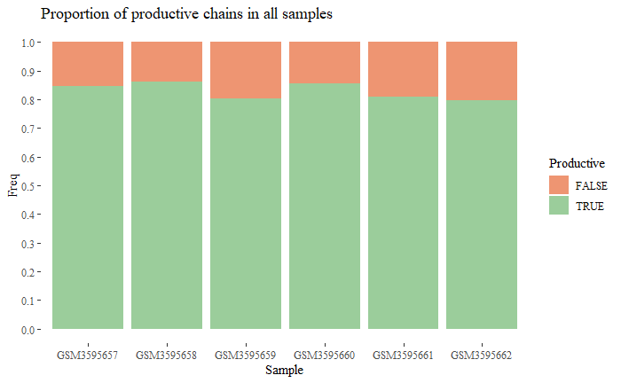

```r
# Count occurences of locus calls in all tables and add a column for sample ID
lapply(seq_along(igblast_results), function(i) {
  table(igblast_results[[i]]$productive) %>%
  as.data.frame() %>% data.frame(., Sample = names(igblast_results)[i]) %>%
    {
      colnames(.)[1] <- 'Productive'
      .
    }
}) %>%
# Generate a unique table and clean up the Var1 column (change name, change empty string to 'Other', relevel)
  bind_rows() %>%
# Plot
  ggplot(aes(x=Sample, y=Freq, fill=Productive)) +
  geom_bar(stat='identity', position='fill') +
  theme_tufte() +
  scale_fill_manual(values=c('lightsalmon2', 'darkseagreen3')) +
  ggtitle('Proportion of productive chains in all samples') +
  scale_y_continuous(breaks=seq(0, 1, 0.1))
```

CCL: Between 80 and 90 % of sequences contain productive chains.

### Alignment scores for V and J genes

D genes are very small and subject to intense somatic hypermutation, so we won’t really worry about the alignment scores. The CDR3 region, which contains the product of the D gene, will be analyzed later on.

[output not shown]

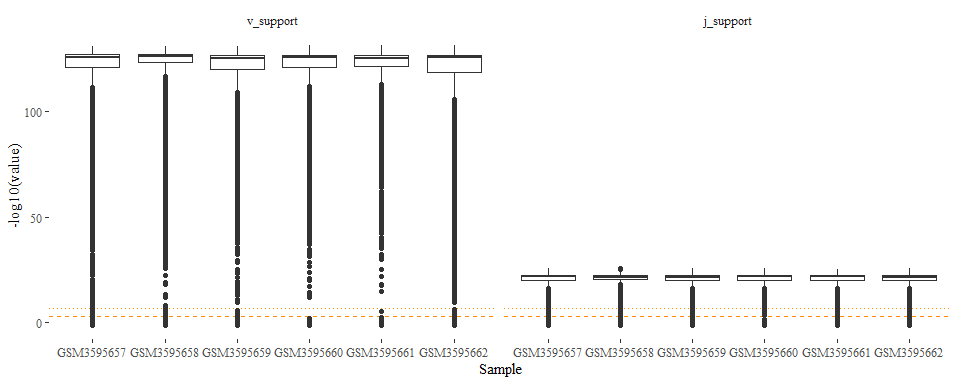

```r
# Extract E values for alignments of interest
lapply(seq_along(igblast_results), function(i) {
  igblast_results[[i]][, c('v_support', 'j_support')] %>%
    melt() %>%
    data.frame(Sample=names(igblast_results)[i])
}) %>%
# Plot
  bind_rows() %>%
  ggplot(aes(x=Sample, y=-log10(value))) +
  geom_hline(yintercept = -log(0.05), col='darkorange', linetype=2) +
  geom_hline(yintercept = -log(0.001), col='darkorange', linetype=3) +
  geom_boxplot() +
  theme(aspect.ratio = 0.3) +
  facet_grid(~variable) +
  theme_tufte()
```

CCL: Most alignments are called with high confidence. All samples are comparable.

## Data filtering

Criteria: - Locus call = TRB - Chain is productive - E value for V and J genes below 0.05

```r
igblast_results_filtered <- lapply(igblast_results, function(x)
  x[x$locus == 'TRB' &
    x$productive &
    x$v_support < 0.05 &
    x$j_support < 0.05, ])
names(igblast_results_filtered) <- names(igblast_results)
```

```r
igblast_results_filtered[[1]][1:5, 1:5]
```

|  | sequence_id | sequence | locus | stop_codon | vj_in_frame |
| --- | --- | --- | --- | --- | --- |
| 1 | SRR8550225:::44:0:0:0:;0.891135 | CTAATACGACTCCGAATTCCCACGCATCCTGAGAAGAAGCATGTCCAACACTGTCCTCGC…… | TRB | FALSE | TRUE |
| 2 | SRR8550225:::52:0:0:0:;0.809257 | CTAATACGACTCCGAATTCCCCCCGCCTGGAACACCACCCTGCTATCTTGGGTTGCTCTC…… | TRB | FALSE | TRUE |
| 3 | SRR8550225:::34:0:0:0:;0.752452 | CTAATACGACTCCGAATTCCCGTCTAACACTGCCTTCCCTGACCTCGCCTGGAACACCAC…… | TRB | FALSE | TRUE |
| 4 | SRR8550225:::62:0:0:0:;0.884914 | CTAATACGACTCCGAATTCCCTGCCCCACAGAGATAGAGAGAACCTGAGGTCTCAGAGAT…… | TRB | FALSE | TRUE |
| 6 | SRR8550225:::87:0:0:0:;0.851072 | CTAATACGACTCGAATTCCCAAACCACCATGAGAGTTAGGCTCATCTCTGCTGTGGTGCT…… | TRB | FALSE | TRUE |

### How many sequences are we left with?

```r
sapply(igblast_results_filtered, nrow)
```

```
GSM3595657 GSM3595658 GSM3595659 GSM3595660 GSM3595661 GSM3595662
     42440      42652      44684      28914      16471      69458
```

### What proportion of the initial number of sequences does this represent?

```r
round(100 * sapply(igblast_results_filtered, nrow) /
  sapply(igblast_results, nrow), 2)
```

```
GSM3595657 GSM3595658 GSM3595659 GSM3595660 GSM3595661 GSM3595662
     81.08      84.13      76.16      82.20      79.91      74.87
```

CCL: After this filtering step, we removed ~15-25 % of the sequences.

# Sample characterization: general statistics

## Species richness

This measures the number of individual species in each sample. We will perform random subsampling to compare all 6 samples

```r
# subsample tables and subset appropriate columns, use only complete cases to avoid missing values dominating the count tables
set.seed(45)
igblast_diversity_table <- lapply(igblast_results_filtered, function(x) {
  x[complete.cases(x[, c('v_call', 'j_call', 'cdr3')]), ]
}) %>%
sapply(nrow) %>%
  min() %>%
  {
    lapply(seq_along(igblast_results_filtered), function(i) {
    igblast_results_filtered[[i]][sample(1:nrow(igblast_results_filtered[[i]]), .), c('v_call', 'j_call', 'cdr3')] %>%
        data.frame(Sample=names(igblast_results_filtered)[i])
  })
  } %>%
# Calculate frequencies for all unique sequences in all samples
  bind_rows() %>%
  plyr::count()
```

```r
igblast_diversity_table[, 'Sample'] %>%
  {
    meta$Description[match(., meta$Sample)]
  } %>%
  table()
```

```
.
Distant tumor 1 Distant tumor 2        Spleen 1        Spleen 2 Treated tumor 1 Treated tumor 2
           2126            3019           14002           14800            2081            1216
```

CCL: The species richness is higher in spleen samples than other samples

## Inverse simpson index

For this analysis, a random subsampling of all samples to the smallest sample size will be performed. The combination of V and J calls and the sequence of the CDR3 will be used to identiy and count unique sequences while minimizing the effect of potential read sequencing errors.

```r
igblast_species_abundance <- igblast_diversity_table %>%
  dcast(Sample ~ v_call + j_call + cdr3, fill=0) %>%
# Add sample description
  {
    rownames(.) <- meta$Description[match(.[, 1], meta$Sample)]
    .[, -1]
    }
```

[output not shown]

```r
igblast_species_abundance %>%
  diversity(index='invsimpson')
```

```
Treated tumor 1 Distant tumor 1        Spleen 1 Treated tumor 2 Distant tumor 2        Spleen 2
      168.74082        18.16342      8737.69053        94.52144       167.96616      9089.41401
```

CCL: Samples obtained from spleen exhibit a much more diverse repertoire than those obtained from tumors

## Highest abundance

```r
igblast_species_abundance %>%
  t() %>%
  as.data.frame() %>%
# Calculate proportion of most abundant species as a percentage for each sample
  sapply(function(x) max(100*x/sum(x)))
```

```
Treated tumor 1 Distant tumor 1        Spleen 1 Treated tumor 2 Distant tumor 2        Spleen 2
      4.8052974      20.7460057       0.3341231       4.9571715       2.8370087       0.4191726
```

##### Plotting species abundance

In this waterfall plot, the 100 most abundant sequences are plotted in each sample, in decreasing order of abundance. Species that are present with an abundance of > 1% are colored in red.

[output not shown]

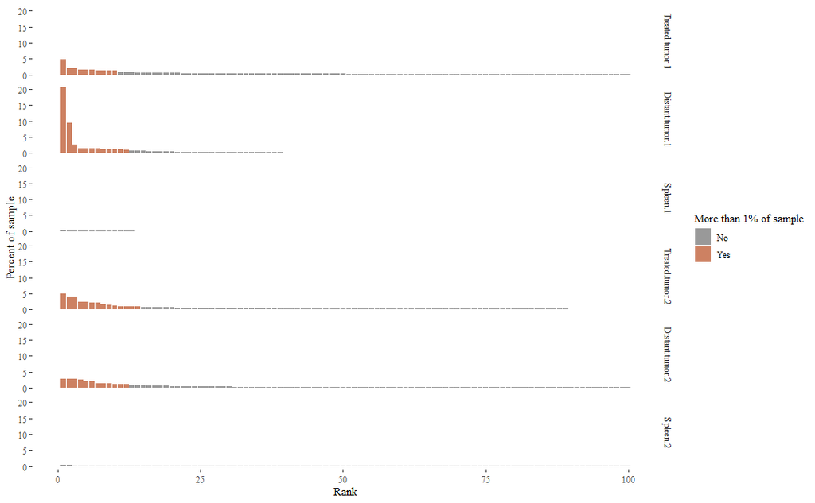

```r
igblast_species_abundance %>%
  t() %>%
  as.data.frame() %>%
  sapply(function(x) 100*x/sum(x)) %>%
  as.data.frame() %>%
  sapply(function(x) sort(x, decreasing = T)) %>%
  as.data.frame() %>%
  data.frame(rank=1:nrow(.)) %>%
  {
    .[1:100, ]
  } %>%
  melt(id.var='rank') %>%
  ggplot(aes(x=rank, y=value, fill=value > 1)) +
  geom_bar(stat='identity') +
  facet_grid(variable~.) +
  theme_tufte() +
  scale_fill_manual(values=c('grey60', 'lightsalmon3'), label=c('No', 'Yes')) +
  xlab('Rank') +
  ylab('Percent of sample') +
  guides(fill=guide_legend(title='More than 1% of sample'))
```

```r
NA
```

CCL: Tumor samples contain TCR beta chains that are over-represented as compared with spleen samples.

## Repertoire dissimilarity index

This is a commonly used measure of the distance between BCR and TCR repertoires. Since it performs random subsampling prior to analysis there is no need to adjust for sample size.

```r
(rdi <- lapply(seq_along(igblast_results), function(i) {
  igblast_results[[i]][, c('v_call', 'd_call', 'j_call')] %>%
  data.frame(Desc=meta$Description[match(names(igblast_results)[i], meta$Sample)])
}) %>% bind_rows() %>%
  {
    rdi(.[, 1:3], .[, 4, drop=F])
  })
```

```
                Distant tumor 1 Distant tumor 2  Spleen 1  Spleen 2 Treated tumor 1
Distant tumor 2       3.2505603
Spleen 1              3.3409613       2.5684981
Spleen 2              3.3507538       2.5804073 0.8370463
Treated tumor 1       3.8004369       2.7710824 2.3190556 2.2508417
Treated tumor 2       3.9047369       2.6938269 2.8203262 2.6867652       2.7657332
```

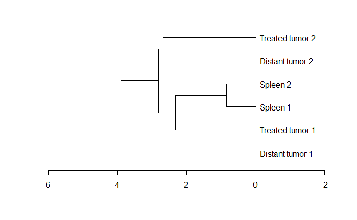

```r
plot(as.dendrogram(hclust(rdi)), horiz=T, asp=0.67)
```

# In depth characterization of the library

## Visualization of chain usage using chord plots

### Data tidying and ordering

```r
# Extract all v_genes present and sort them a first time
(v_genes <- unique(igblast_diversity_table$v_call) %>%
   sort()) %>%
  head()
```

```
[1] "TRBV1*01"    "TRBV1*02"    "TRBV12-1*01" "TRBV12-1*02" "TRBV12-2*01" "TRBV12-2*02"
```

```r
# Sort by the main gene number identifier so that TRBV2 comes next to TRBV1
v_genes <- v_genes[sub('TRBV', '', v_genes) %>%
  substr(1, regexpr("[[:punct:]]", .)-1) %>%
  as.numeric() %>%
  order()]
```

```r
v_genes
```

[output not shown]

```r
# Extract all j_genes present and sort them a first time
(j_genes <- unique(igblast_diversity_table$j_call) %>%
   sort()) %>%
  head()
```

```
[1] "TRBJ1-1*01" "TRBJ1-1*02" "TRBJ1-2*01" "TRBJ1-3*01" "TRBJ1-4*01" "TRBJ1-4*02"
```

```r
# Sort by the main gene number identifier so that TRBV2 comes next to TRBV1
j_genes <- j_genes[sub('TRBV', '', j_genes) %>%
  substr(1, regexpr("[[:punct:]]", .)-1) %>%
  as.numeric() %>%
  order()]
```

```
NAs introduced by coercion
```

```r
j_genes
```

```
 [1] "TRBJ1-1*01" "TRBJ1-1*02" "TRBJ1-2*01" "TRBJ1-3*01" "TRBJ1-4*01" "TRBJ1-4*02" "TRBJ1-5*01" "TRBJ1-5*03" "TRBJ1-6*01"
[10] "TRBJ2-1*01" "TRBJ2-2*01" "TRBJ2-3*01" "TRBJ2-4*01" "TRBJ2-5*01" "TRBJ2-7*01" "TRBJ2-7*02"
```

```r
all_genes <- c(v_genes, j_genes) %>%
  {factor(., levels=.)}
all_genes
```

```
 [1] TRBV1*01    TRBV1*02    TRBV2*01    TRBV3*01    TRBV3*02    TRBV4*01    TRBV5*01    TRBV5*02    TRBV5*03    TRBV5*04
[11] TRBV8*01    TRBV12-1*01 TRBV12-1*02 TRBV12-2*01 TRBV12-2*02 TRBV13-1*01 TRBV13-1*02 TRBV13-2*01 TRBV13-2*03 TRBV13-3*01
[21] TRBV14*01   TRBV15*01   TRBV16*01   TRBV17*01   TRBV19*01   TRBV19*02   TRBV20*01   TRBV20*02   TRBV21*01   TRBV23*01
[31] TRBV24*02   TRBV26*01   TRBV29*01   TRBV30*01   TRBV31*01   TRBV31*02   TRBJ1-1*01  TRBJ1-1*02  TRBJ1-2*01  TRBJ1-3*01
[41] TRBJ1-4*01  TRBJ1-4*02  TRBJ1-5*01  TRBJ1-5*03  TRBJ1-6*01  TRBJ2-1*01  TRBJ2-2*01  TRBJ2-3*01  TRBJ2-4*01  TRBJ2-5*01
[51] TRBJ2-7*01  TRBJ2-7*02
52 Levels: TRBV1*01 TRBV1*02 TRBV2*01 TRBV3*01 TRBV3*02 TRBV4*01 TRBV5*01 TRBV5*02 TRBV5*03 TRBV5*04 TRBV8*01 ... TRBJ2-7*02
```

### Chord/circos plot parameter settings

```r
plot_circos <- function(sample_index) {

  # Subset part of data table with data relevant to the particular sample
  link_data <- igblast_diversity_table[igblast_diversity_table$Sample == meta$Sample[sample_index], ] %>%
    {aggregate(.$freq, by=list(v_call=.$v_call, j_call=.$j_call), sum)}

  # Calculate x coordinates for circos track (width of each sector)
  sector_data <- data.frame(genes=all_genes, xmin=0, xmax=1+sapply(all_genes, function(x) sum(link_data$x[link_data$v_call == x | link_data$j_call == x])))

  # Generate colors for TRBV genes
  set.seed(50)
  sector_data$scolor <- ifelse(grepl('V', sector_data$genes),
                              sample(colorRampPalette(c('lightsalmon2', 'lightgoldenrod', 'darkslategray3'))(sum(grepl('V', sector_data$genes)))),
                              'gray75')
  sector_data$lcolor <- alpha(sector_data$scolor, 0.5)

  # Calculate coordinates of links for circos
  # For more esthetic plot, opposite gene set was reverse-ordered before calculations
  link_data <- link_data[link_data$x > 10, ]
  link_data <- link_data[order(link_data$j_call, decreasing = T), ]
  link_data <- link_data[order(link_data$v_call), ]
  link_data$x1 <- sapply(1:nrow(link_data), function(i) {
   x <- link_data$v_call[i]
   sum(link_data$x[which((link_data$v_call == x)[1:i-1])])
  })
  link_data <- link_data[order(link_data$v_call, decreasing = T), ]
  link_data <- link_data[order(link_data$j_call), ]
  link_data$x2 <- sapply(1:nrow(link_data), function(i) {
   x <- link_data$j_call[i]
   sum(link_data$x[which((link_data$j_call == x)[1:i-1])])
  })

  # Set up plot canvas parameters
  par(mar=rep(1,4))
  circos.clear()

  # Set up graphic parameters
  circos.par(cell.padding=c(0,0,0,0), track.margin=c(0,0.02), start.degree = 180, gap.degree =2,
             canvas.xlim=c(-1.25, 1.25), canvas.ylim=c(-1.25, 1.25))

  # Initialization of sectors
  circos.initialize(factors = sector_data$genes, xlim = cbind(sector_data$xmin, sector_data$xmax))

  # Plot outer sectors
  circos.trackPlotRegion(ylim = c(0, 1), factors = sector_data$genes, track.height=0.1,
                        #panel.fun for each sector
                        panel.fun = function(x, y) {
                        #select details of current sector
                        name = get.cell.meta.data("sector.index")
                        i = get.cell.meta.data("sector.numeric.index")
                        xlim = get.cell.meta.data("xlim")
                        ylim = get.cell.meta.data("ylim")

                        #text direction (dd) and adjusmtents (aa)
                        theta = circlize(mean(xlim), 1.3)[1, 1] %% 360
                        dd <- ifelse(theta < 90 || theta > 270, "clockwise", "reverse.clockwise")
                        aa = c(1, 0.5)
                        if(theta < 90 || theta > 270)  aa = c(0, 0.5)

                        #plot country labels
                        circos.text(x=mean(xlim), y=1, labels=name, facing = dd, cex=0.6,  adj = aa)

                        #plot main sector
                        circos.rect(xleft=xlim[1], ybottom=ylim[1], xright=xlim[2], ytop=ylim[2],
                                    col=sector_data$scolor[i], border=sector_data$scolor[i])
                      })


  # Plot links

  # Randomize links
  # set.seed(62)
  # link_data <- link_data[sample(1:nrow(link_data)), ]

  # Draw links
  for(k in 1:nrow(link_data)){
      # cross-reference data frame with link values to data frame with sectors
      i<-match(link_data$v_call[k],sector_data$genes)
      j<-match(link_data$j_call[k],sector_data$genes)

  circos.link(sector.index1=sector_data$genes[i], point1=c(link_data$x1[k], link_data$x1[k] + link_data$x[k]),
              sector.index2=sector_data$genes[j], point2=c(link_data$x2[k], link_data$x2[k] + link_data$x[k]),
              col=sector_data$lcolor[i])

  }
  title(meta$Description[sample_index])
}
```

### Results

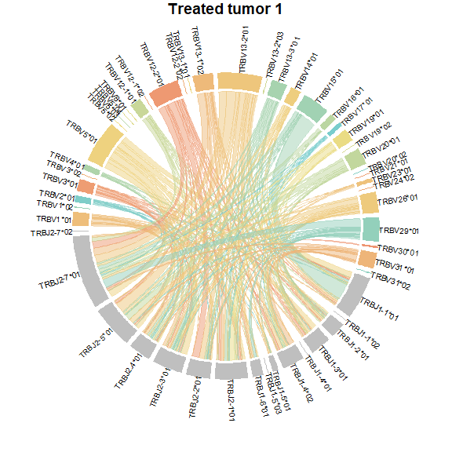

```r
plot_circos(1)
```

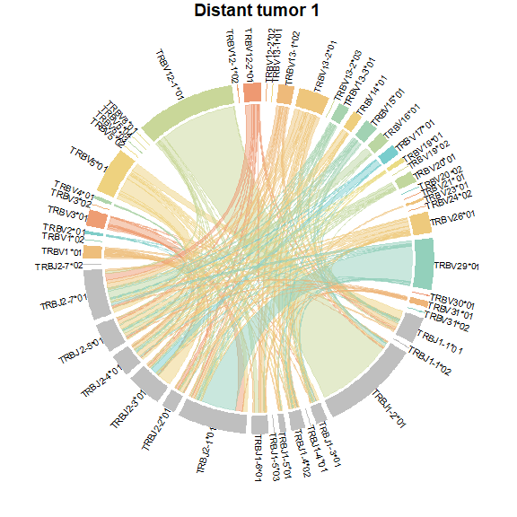

```r
plot_circos(2)
```

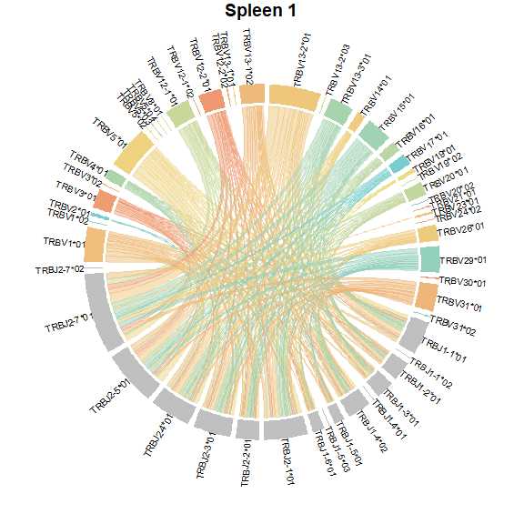

```r
plot_circos(3)
```

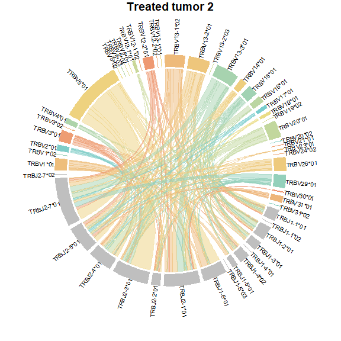

```r
plot_circos(4)
```

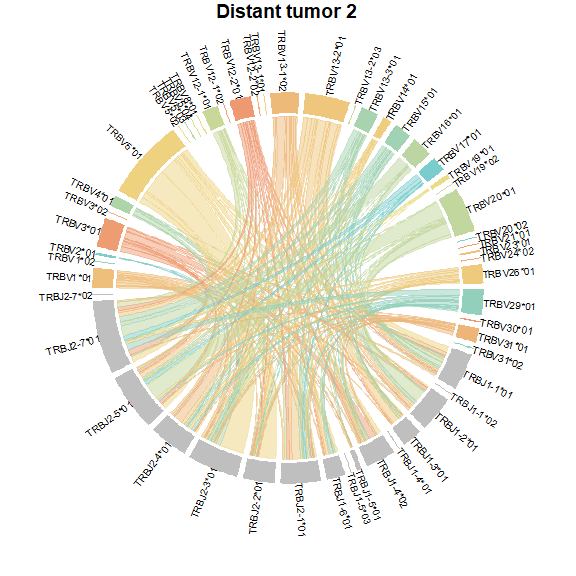

```r
plot_circos(5)
```

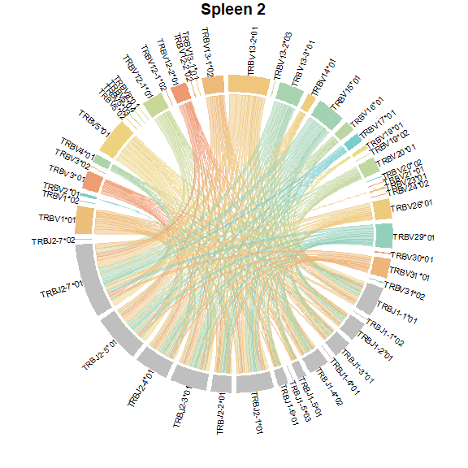

```r
plot_circos(6)
```

CCL: Tumor samples exhibits a bias in VJ chain combination which is likely the result of over-representation of specific T-cell clones in the tumor.